# INLAcircular: User Guide and Function Reference

Xiang Ye

[figure not shown]

# 1 Scope and conventions

INLAcircular provides probability functions and a model-building interface for Bayesian circular and joint circular regression with Integrated Nested Laplace Approximation (INLA). Its core numerical routines are written in C and exposed through ordinary R functions.

The package follows these conventions:

- Angles are measured in radians.
- Location parameters are named `mu`.
- Concentration parameters are named `kappa`, including for cardioid and wrapped Cauchy distributions.
- Density functions use `log = TRUE` for log-densities.
- PC-prior distribution and quantile functions use

  ```
  log.p =
  TRUE
  ```

  for probabilities on the log scale.
- The d/p/q/r prefix has its usual R meaning: density, distribution function, quantile function, and random generation.

The core distribution and PC-prior functions can be used without `INLA`. Model fitting requires the optional `INLA` package, and LKJ multivariate random effects also require `graphpcor`.

# 2 Installation

After the package is published on CRAN, install it with:

```r
install.packages("INLAcircular")
```

The installation above provides the circular distributions and PC-prior functions without installing INLA. For model fitting, install optional INLA >= 25.08.21 from the current stable repository separately:

```r
install.packages(
  "INLA",
  repos = c(
    getOption("repos"),
    INLA = "https://inla.r-inla-download.org/R/stable"
  )
)
```

For a development installation from GitHub:

```r
install.packages("remotes")
remotes::install_github(
  "XiangYEstats/INLAcircular"
)
```

```r
library(INLAcircular)
```

Attaching INLA is optional because `INLAcircular` loads its namespace when a model-fitting function needs it. If both packages are attached and you want the compatibility `inla()` function on the search path, load `INLA` first and then `INLAcircular`.

# 3 Circular distributions

## 3.1 Quick comparison

The package supplies the full d/p/q/r interface for the von Mises and link-adjusted von Mises distributions. It supplies compiled densities for the cardioid and wrapped Cauchy distributions.

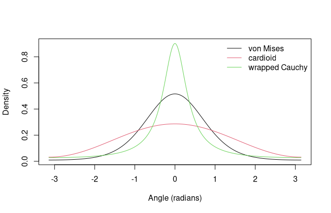

Three circular density families with mean direction zero.

```r
theta <- seq(-pi, pi, length.out = 361)
densities <- cbind(
  "von Mises" = dvm(theta, mu = 0, kappa = 2),
  "cardioid" = dcardioid(theta, mu = 0, kappa = 0.4),
  "wrapped Cauchy" =
    dwrappedcauchy(theta, mu = 0, kappa = 0.7)
)

matplot(
  theta,
  densities,
  type = "l",
  lty = 1,
  xlab = "Angle (radians)",
  ylab = "Density"
)
legend(
  "topright",
  legend = colnames(densities),
  col = seq_len(ncol(densities)),
  lty = 1,
  bty = "n"
)
```

## 3.2 Von Mises

`dvm()`, `pvm()`, `qvm()`, and `rvm()` evaluate the von Mises distribution with density

$$f(x\mid\mu,\kappa)
=\frac{\exp\{\kappa\cos(x-\mu)\}}{2\pi I_0(\kappa)}.$$

`kappa = 0` gives the circular uniform limit. The CDF and quantile functions use a cached spline grid; `len` controls its resolution. With `strategy = “circular”`, the CDF origin follows the mean direction. The alternative

```
strategy =
“linear”
```

retains a fixed linear representation.

```r
set.seed(1)
rvm(5, mu = 0, kappa = 3)
```

```
#> [1] -0.3859961 -0.2006438  0.1103994  0.8385810 -0.5174967
```

```r
pvm(pi / 2, mu = 0, kappa = 2)
```

```
#> [1] 0.9625691
```

```r
qvm(0.95, mu = 0, kappa = 2)
```

```
#> [1] 1.416584
```

## 3.3 Link-adjusted von Mises

`dlavm()`, `plavm()`, `qlavm()`, and `rlavm()` use a linear predictor `eta` and concentration `kappa`. The current direct distribution interface uses the inverse-tangent transformation

$$z=2\arctan\{\tan(x/2)-\eta\}.$$

`lavm.link(“tan”)` returns the corresponding transformation and inverse functions. The `link_obj` argument in the p/q/r functions is reserved for interface compatibility; the current compiled implementation uses the inverse-tangent link.

```r
set.seed(2)
rlavm(5, eta = 1.5, kappa = 3)
```

```
#> [1] 1.763773 2.058985 1.998958 1.745235 2.237412
```

```r
dlavm(c(-1, 0, 1), eta = 1.5, kappa = 3)
```

```
#> [1] 0.001291978 0.003164735 0.025559191
```

```r
plavm(pi / 2, eta = 1.5, kappa = 3)
```

```
#> [1] 0.07300838
```

```r
qlavm(0.5, eta = 1.5, kappa = 3)
```

```
#> [1] 1.965116
```

## 3.4 Cardioid and wrapped Cauchy densities

The cardioid density is

$$f_{\mathrm{card}}(x\mid\mu,\kappa)
=\frac{1+2\kappa\cos(x-\mu)}{2\pi},
\qquad 0\leq\kappa\leq\frac12.$$

Use `dcardioid()`, or its short alias `dcard()`.

The wrapped Cauchy density is

$$f_{\mathrm{wc}}(x\mid\mu,\kappa)
=\frac{1-\kappa^2}
{2\pi\{1+\kappa^2-2\kappa\cos(x-\mu)\}},
\qquad 0\leq\kappa<1.$$

Use `dwrappedcauchy()`, or its short alias `dwc()`. The endpoint `kappa = 1` is a point-mass limit: the compiled density reports `Inf` at the mean direction and zero elsewhere. Finite-parameter likelihoods should use `kappa < 1`.

Both functions recycle `x`, `mu`, and `kappa` to a common length.

```r
x <- c(-pi / 2, 0, pi / 2)
dcardioid(x, mu = 0, kappa = c(0, 0.25, 0.5))
```

```
#> [1] 0.1591549 0.2387324 0.1591549
```

```r
dwrappedcauchy(x, mu = 0, kappa = 0.7, log = TRUE)
```

```
#> [1] -2.909998 -0.103276 -2.909998
```

# 4 Penalized-complexity priors

A PC prior assigns an exponential distribution with rate `lambda` to a distance from a simpler base model. Larger `lambda` puts more prior mass near the base. All five prior families expose matching density, CDF, quantile, and random-generation functions.

| Help topic | Base model | Support for kappa | Special behavior |
| --- | --- | --- | --- |
| pc.vm0 | von Mises uniform limit, kappa = 0 | [0, Inf) | Continuous |
| pc.vminf | von Mises point-mass limit | [0, Inf) | Atom exp(-lambda) at zero |
| pc.card0 | cardioid uniform model, kappa = 0 | [0, 1/2] | Normalized truncated exponential distance |
| pc.card | cardioid base, kappa = 1/2 | [0, 1/2] | Atom at zero; integrable singularity at 1/2 |
| pc.wc | wrapped Cauchy uniform model, kappa = 0 | [0, 1) | Continuous; open upper endpoint |

For a monotone distance $d(\kappa)$, an untruncated continuous PC prior has density

$$\pi(\kappa)=\lambda\exp\{-\lambda d(\kappa)\}
\left|d'(\kappa)\right|.$$

When the attainable distance range is bounded, the remaining exponential tail must be handled explicitly. `pc.card0` truncates and normalizes the exponential distance law; `pc.vminf` and `pc.card` collapse the remaining tail to a boundary atom. The density functions below return densities with respect to Lebesgue measure. A boundary atom is therefore represented by the CDF and RNG, not added to the value returned by a density function.

## 4.1 Von Mises prior with uniform base: pc.vm0

Write

$$A(\kappa)=\frac{I_1(\kappa)}{I_0(\kappa)},\qquad
A'(\kappa)=1-A(\kappa)^2-\frac{A(\kappa)}{\kappa},$$

where the continuous limit is $A'(0)=1/2$. The distance from the circular uniform model is

$$d_0(\kappa)=
\sqrt{\kappa A(\kappa)-\log I_0(\kappa)}.$$

For $\kappa>0$, the density and CDF are

$$\boxed{
\pi_0(\kappa)=
\lambda e^{-\lambda d_0(\kappa)}
\frac{\kappa A'(\kappa)}{2d_0(\kappa)}
},\qquad
F_0(\kappa)=1-e^{-\lambda d_0(\kappa)}.$$

The density has the finite endpoint limit $\pi_0(0)=\lambda/2$. This is a continuous distribution with no atom at zero. Use `dpc.vm0()`, `ppc.vm0()`, `qpc.vm0()`, and `rpc.vm0()`.

```r
probability <- c(0.1, 0.5, 0.9)
q0 <- qpc.vm0(probability, lambda = 2)
cbind(
  probability = probability,
  quantile = q0,
  recovered = ppc.vm0(q0, lambda = 2)
)
```

```
#>      probability  quantile recovered
#> [1,]         0.1 0.1054703       0.1
#> [2,]         0.5 0.7266853       0.5
#> [3,]         0.9 6.6791614       0.9
```

```r
dpc.vm0(c(0, 0.5, 2), lambda = 2)
```

```
#> [1] 1.00000000 0.57267102 0.09577906
```

## 4.2 Von Mises prior with point-mass base: pc.vminf

The distance from the point-mass limit $\kappa\rightarrow\infty$ is

$$d_\infty(\kappa)=\sqrt{1-A(\kappa)}.$$

The continuous density for $\kappa>0$ and the full CDF are

$$\boxed{
\pi_\infty^{\mathrm{cont}}(\kappa)=
\lambda e^{-\lambda d_\infty(\kappa)}
\frac{A'(\kappa)}{2d_\infty(\kappa)}
},\qquad
F_\infty(\kappa)=e^{-\lambda d_\infty(\kappa)}.$$

Because $d_\infty(0)=1$, the full law has boundary mass $\Pr(\kappa=0)=e^{-\lambda}$. `dpc.vminf()` returns only the continuous component, whose right-hand endpoint limit is $\lambda e^{-\lambda}/4$. `ppc.vminf()`, `qpc.vminf()`, and `rpc.vminf()` include the atom.

```r
lambda <- 2
atom_vm <- exp(-lambda)
c(computed = ppc.vminf(0, lambda), expected = atom_vm)
```

```
#>  computed  expected
#> 0.1353353 0.1353353
```

```r
dpc.vminf(c(0, 0.5, 2), lambda)
```

```
#> [1] 0.06766764 0.09193625 0.09948602
```

```r
qpc.vminf(c(atom_vm / 2, (1 + atom_vm) / 2), lambda)
```

```
#> [1] 0.000000 6.527716
```

## 4.3 Cardioid prior with uniform base: pc.card0

Let

$$s(\kappa)=\sqrt{1-4\kappa^2},\qquad
d_0(\kappa)=
\sqrt{1-s(\kappa)+\log\{(1+s(\kappa))/2\}}.$$

The distance is bounded above by $D_0=\sqrt{1-\log 2}$. Therefore pc.card0 uses the normalized, truncated exponential density

$$\boxed{
\pi_0(\kappa)=
\frac{\lambda e^{-\lambda d_0(\kappa)}}
{1-e^{-\lambda D_0}}
\frac{2\kappa}{\{1+s(\kappa)\}d_0(\kappa)}
}.$$

Its CDF is

$$F_0(\kappa)=
\frac{1-\exp\{-\lambda d_0(\kappa)\}}
{1-\exp(-\lambda D_0)}.$$

Use `dpc.card0()`, `ppc.card0()`, `qpc.card0()`, and `rpc.card0()`. The density at zero is evaluated by continuity and equals $\lambda/\{1-e^{-\lambda D_0}\}$. At $\kappa=1/2$, it equals $\lambda e^{-\lambda D_0}/[D_0\{1-e^{-\lambda D_0}\}]$.

```r
probability <- c(0.1, 0.5, 0.9)
quantile <- qpc.card0(probability, lambda = 2)
cbind(
  probability = probability,
  quantile = quantile,
  recovered = ppc.card0(quantile, lambda = 2)
)
```

```
#>      probability   quantile recovered
#> [1,]         0.1 0.03465088       0.1
#> [2,]         0.5 0.20172637       0.5
#> [3,]         0.9 0.43368208       0.9
```

```r
dpc.card0(c(0, 0.25, 0.5), lambda = 2)
```

```
#> [1] 2.986217 1.892776 1.780359
```

## 4.4 Cardioid prior with base kappa = 1/2: pc.card

The distance to the concentrated cardioid base is

$$d_{1/2}(\kappa)=
\sqrt{1-2\kappa-s(\kappa)+\log\{1+s(\kappa)\}}.$$

It decreases from $\sqrt{\log 2}$ at zero to zero at the base. Its continuous density is

$$\boxed{
\pi_{1/2}^{\mathrm{cont}}(\kappa)=
\lambda e^{-\lambda d_{1/2}(\kappa)}
\frac{1+s(\kappa)-2\kappa}
{\{1+s(\kappa)\}d_{1/2}(\kappa)}
}.$$

The full CDF is

$$F_{1/2}(\kappa)=\exp\{-\lambda d_{1/2}(\kappa)\}.$$

Consequently, the distribution has boundary mass $\exp\{-\lambda\sqrt{\log 2}\}$ at `kappa = 0`. `dpc.card()` returns the continuous density component. `ppc.card()`, `qpc.card()`, and `rpc.card()` include the atom. The continuous density tends to `Inf` at `kappa = 0.5`, but the singularity is integrable. At zero, its continuous component is $\lambda e^{-\lambda\sqrt{\log 2}}/\sqrt{\log 2}$; this value is distinct from the atom probability.

```r
lambda <- 2
atom_card <- exp(-lambda * sqrt(log(2)))
c(computed = ppc.card(0, lambda), expected = atom_card)
```

```
#> computed expected
#>  0.18917  0.18917
```

```r
qpc.card(c(atom_card / 2, (1 + atom_card) / 2), lambda)
```

```
#> [1] 0.0000000 0.4024443
```

```r
dpc.card(c(0, 0.25, 0.49), lambda)
```

```
#> [1] 0.4544326 1.0445693 6.6278466
```

## 4.5 Wrapped Cauchy prior: pc.wc

For the wrapped Cauchy family,

$$d_{\mathrm{wc}}(\kappa)=\sqrt{-\log(1-\kappa^2)}$$

maps [0, 1) to the full nonnegative distance axis. Its density is

$$\boxed{
\pi_{\mathrm{wc}}(\kappa)=
\lambda e^{-\lambda d_{\mathrm{wc}}(\kappa)}
\frac{\kappa}{(1-\kappa^2)d_{\mathrm{wc}}(\kappa)}
}.$$

The CDF is

$$F_{\mathrm{wc}}(\kappa)
=1-\exp\{-\lambda d_{\mathrm{wc}}(\kappa)\}.$$

Use `dpc.wc()`, `ppc.wc()`, `qpc.wc()`, and `rpc.wc()`. The density limit at zero is `lambda`; the density diverges as `kappa` approaches one. Interior-probability quantiles (`0 < p < 1`) and RNG output remain strictly below one. There is no atom at one; the value `dpc.wc(1, lambda)` is the limiting density convention.

```r
q_wc <- qpc.wc(c(0.1, 0.5, 0.9), lambda = 2)
cbind(quantile = q_wc, recovered = ppc.wc(q_wc, lambda = 2))
```

```
#>        quantile recovered
#> [1,] 0.05264373       0.1
#> [2,] 0.33642236       0.5
#> [3,] 0.85692657       0.9
```

```r
set.seed(3)
rpc.wc(5, lambda = 2)
```

```
#> [1] 0.09179213 0.70196661 0.23947530 0.19660997 0.43736859
```

```r
dpc.wc(c(0, 0.5, 0.9), lambda = 2)
```

```
#> [1] 2.0000000 0.8503661 0.5585013
```

## 4.6 Density, probability, and vectorization rules

Every family follows the same call pattern:

```r
dpc.NAME(kappa, lambda, log = FALSE)
ppc.NAME(q, lambda, log.p = FALSE)
qpc.NAME(p, lambda, log.p = FALSE)
rpc.NAME(n, lambda)
```

The PC-prior functions recycle concentrations or probabilities against `lambda`. The rate must always contain positive, finite values. With `log.p = TRUE`, CDFs return log-probabilities and quantiles accept log-probabilities. The density flag is `log`, and both flags must be one non-missing logical value. There is no `lower.tail` argument; all probabilities are lower-tail.

Values and `lambda` recycle to their common maximum length, with a warning for non-multiple lengths. For random generation, a vector `n` requests `length(n)` draws; otherwise its scalar value is converted to an integer. The generators use R’s RNG stream. Apart from the documented limiting-endpoint conventions, densities are zero outside their mathematical support, while invalid probabilities produce `NaN`.

Names such as `pc.card0` are help topics and prior labels, not callable R functions. Use the corresponding d/p/q/r functions.

```r
dpc.card0(c(0.1, 0.2, 0.3), lambda = c(1, 2, 3), log = TRUE)
```

```
#> [1] 0.7622848 0.7219704 0.4663980
```

```r
qpc.wc(log(c(0.1, 0.5, 0.9)), lambda = 2, log.p = TRUE)
```

```
#> [1] 0.05264373 0.33642236 0.85692657
```

# 5 Direct fitting with R-INLA

This section uses `INLA::inla()` literally. The LAvM likelihood in this package is an external compiled `cloglike`, so a direct call has three explicit preparation steps:

1. convert the circular response with `INLA::inla.mdata()`;
2. construct the compiled likelihood with `lavm.cloglike()`; and
3. call `INLA::inla()` with

   ```
   family =
   “cloglike”
   ```

   .

```r
lavm_setting <- list(
  link = "inverse.tangent",
  hyper = list(
    kappa = list(
      initial = log(50),
      prior = "pc.vminf",
      param = c(0.5, 0.5),
      fixed = FALSE
    )
  )
)

direct_data <- list(
  angle_lavm = INLA::inla.mdata(angle),
  z = z
)

fit_direct <- INLA::inla(
  angle_lavm ~ z,
  family = "cloglike",
  data = direct_data,
  control.family = list(
    cloglike = lavm.cloglike(lavm_setting)
  ),
  control.inla = list(
    cmin = 0,
    compute.initial.values = TRUE
  ),
  control.compute = list(cpo = TRUE, dic = TRUE, waic = TRUE),
  verbose = FALSE
)
```

Do not replace `family = “cloglike”` by

```
family =
“lavm”
```

in this namespaced call. Some INLA versions have an experimental native family with that name, but its links, hyperparameter names, and priors are different from the INLAcircular LAvM interface. The custom prior names `pc.vm0` and `pc.vminf` are implemented inside this package’s cloglike.

## 5.1 LAvM likelihood controls

`lavm.cloglike(family.setting)` accepts the following controls:

If $\kappa_u$ solves $A(\kappa_u)=u$, `pc.vm0` uses

$$\lambda=-\frac{\log(\alpha)}{d_0(\kappa_u)},$$

whereas `pc.vminf` uses

$$\lambda=-\frac{\log(1-\alpha)}{\sqrt{1-u}}.$$

This `c(u, alpha)` interface differs from the standalone d/p/q/r functions, which take `lambda` directly. The obsolete names `hyper$prec` and `log.initial` are rejected.

For `pc.vminf`, this calibration comes from the full PC law, including its atom at `kappa = 0`. A fitted INLA hyperparameter is finite $\theta=\log(\kappa)$, so the cloglike evaluates only the continuous component transformed to the $\theta$ scale, including its Jacobian. It has no separate discrete state at $\theta=-\infty$. Treat

```
c(u,
alpha)
```

as the rate calibration for the fitted continuous prior, not as a claim that the fitted hyperparameter retains the boundary atom.

For numerical stability, the compiled cloglike evaluates its likelihood and prior after restricting the working value of $\theta$ to $[-30,30]$. This matters only at extreme concentrations, but is relevant when selecting initial values or diagnosing an optimizer at a boundary.

The literal lower-level fit retains ordinary INLA cloglike names and the internal $\log(\kappa)$ marginal. Transform it when needed:

```r
theta_name <- grep(
  "^Theta1 for",
  names(fit_direct$marginals.hyperpar),
  value = TRUE
)[1]
kappa_marginal <- INLA::inla.tmarginal(
  exp,
  fit_direct$marginals.hyperpar[[theta_name]]
)
INLA::inla.zmarginal(kappa_marginal)
```

## 5.2 Convenience call for a single LAvM model

Loading INLA first and INLAcircular second makes the package’s compatibility function available as the unqualified `inla()`. It accepts `family = “lavm”`, performs the three preparation steps above, and renames the concentration output onto the natural kappa scale.

```r
library(INLA)
library(INLAcircular)

fit_short <- inla(
  angle ~ z,
  family = "lavm",
  data = data.frame(angle = angle, z = z),
  control.family = lavm_setting
)
```

Use `INLA::inla()` for the explicit low-level interface and for ordinary INLA families. Use the unqualified `inla()` form above only when you intentionally want the package’s LAvM compatibility layer.

# 6 Building model specifications

`inlacc()` uses a formula-building layer to assemble one or more likelihood blocks into a stacked INLA model. Create one response block with

```r
likelihood(formula, family, family.setting = NULL)
```

Its arguments are:

- `formula`: a two-sided formula for one response. The left side should be a single column name in `data`.
- `family`: one INLA likelihood name. Use `“lavm”` for the package’s link-adjusted von Mises likelihood; other names are passed to INLA.
- `family.setting`: the `control.family` list for this block. For LAvM it has the structure documented in the preceding section.

A single likelihood object can be passed directly to `inlacc()`. A joint model is a list. Likelihood order determines response-block order and, where relevant, multivariate component order.

```r
angle_model <- likelihood(
  angle ~
    intercept(name = "alpha0", mean = 0, sd = 2) +
    covariate(z, name = "alpha_z", mean = 0, sd = 1) +
    f(
      hour_effect,
      model = "rw1",
      cyclic = TRUE,
      constr = TRUE,
      scale.model = TRUE,
      hyper = list(
        prec = list(
          prior = "pc.prec",
          param = c(1, 0.01)
        )
      )
    ),
  family = "lavm",
  family.setting = lavm_setting
)
```

## 6.1 Formula terms and their interpretation

The right side may contain ordinary numeric fixed-effect expressions and the following markers:

| Term | Meaning inside `inlacc()` |
| --- | --- |
| `1` | Automatic block-specific intercept named `Intercept_<response>` |
| `0` or `-1` | Remove the automatic intercept |
| `intercept(...)` | Named intercept with an optional Gaussian prior |
| ordinary term such as `z` or `log(z)` | Block-specific fixed effect evaluated in `data` |
| `covariate(...)` | Fixed effect or automatically/explicitly copied response predictor |
| `f(...)` | Standard INLA latent-effect term, passed into the assembled formula |

Use numeric columns and expressions for ordinary terms. The assembler does not reproduce every `model.matrix()` feature for factors, offsets, or special response expressions. Use unique custom coefficient names across likelihoods unless a shared fixed coefficient is intentional.

### 6.1.1 `intercept()`

```r
intercept(name = NULL, mean = NULL, sd = NULL)
```

- `name` changes the coefficient label; its default is `Intercept_<response>`.
- `mean` and `sd` set the Gaussian prior. A missing value inherits the corresponding global fixed-effect setting.
- A formula `0` or `-1` removes the automatic intercept, while an explicit `intercept()` adds the custom one.

This is a formula marker. It returns `NULL` when called by itself because `inlacc()` interprets its unevaluated call.

### 6.1.2 `covariate()`

```r
covariate(
  var,
  name = NULL,
  mean = NULL,
  sd = NULL,
  initial = NULL,
  fixed = FALSE,
  predictor = NULL
)
```

- `var` is an unquoted variable or expression evaluated in `data`. It is an argument, not a separate function named `var()`.
- `name` supplies a stable coefficient and display name.
- `mean` and `sd` independently override the Gaussian prior for an ordinary fixed effect.
- `predictor = NULL`, the default, copies the latent predictor when `var` is an untransformed response in another likelihood block; otherwise it creates an ordinary observed fixed effect.
- `predictor = TRUE` explicitly requests copying. It is an error if `var` is not an untransformed response from another block.
- `predictor = FALSE` always creates an ordinary fixed effect from the observed values, including when `var` is another response.
- `initial` and `fixed` control the INLA copy-scaling coefficient. They apply to copied predictors and are not used for ordinary fixed effects.

For a copied predictor, provide both `mean` and `sd` to customize its scaling prior. If either is absent, the current implementation uses its default $N(0,31.62^2)$ scaling prior. Any response used directly as a bare term on another block’s right side is also copied automatically. To use that response’s observed values instead, write `covariate(response, predictor = FALSE)`. A transformed expression such as `log(response)` is an ordinary observed fixed effect under `predictor = NULL` or `FALSE`; requesting `predictor = TRUE` for a transformed expression is an error because this interface can copy only a named source predictor.

### 6.1.3 `f()` and standard INLA options

INLAcircular does not export a separate `f()`. Write a bare `f(…)` in an `inlacc()` formula. Its syntax is the R-INLA latent-effect syntax, including `model`, `hyper`, `constr`, `scale.model`, `cyclic`, `group`, `control.group`, `replicate`, `values`, and `copy`. Use `INLA::inla.doc()` for details of the selected latent model.

The term is preserved in the assembled INLA formula. INLAcircular additionally does the following:

- supplies an index column from `data` or `index()`;
- creates `1:nrow(data)` when an index is otherwise absent;
- injects or replaces `values` for the matching first index when a complete `process.id` is given;
- records common model and hyperprior information for summaries; and
- rewrites the special `model = “iidkd_LKJ”` form described later.

Because the preprocessor recognizes the call name literally, use `f(…)`, not `INLA::f(…)`, in these formulas.

## 6.2 Mapping observations with `index()`

```r
index(var, data.id, process.id = NULL)
```

Here `data.id` and `process.id` are arguments of `index()`, not separate functions.

- `var` is a character string matching the first argument of an `f()` term.
- `data.id` maps each observation row to a latent-process node and should normally have `nrow(data)` entries.
- `process.id` optionally gives the complete ordered node set. When supplied, it becomes the INLA `values` argument for an `f()` term whose first argument matches `var`, replacing any existing `values` argument. When it is `NULL`, INLA infers represented values from the observation index. A mapping can supply `data.id` for a first, group, or replicate variable, but `process.id` applies only to a matching first index.

```r
hour_index <- index(
  var = "hour_effect",
  data.id = c(1, 2, 2, 4),
  process.id = 1:4
)

hour_index
```

```
#> $var
#> [1] "hour_effect"
#>
#> $data.id
#> [1] 1 2 2 4
#>
#> $process.id
#> [1] 1 2 3 4
```

Pass one object directly or several in a list:

```r
latent_indices <- list(
  index("hour_effect", data.id = data$hour, process.id = 0:23),
  index("region_effect", data.id = data$region, process.id = region_ids)
)
```

If a mapped name is not used by any `f()` first, group, or replicate argument, it is ignored with a warning. For an ordinary shared effect, `index(var, data.id = “likelihood”)` sets its index to the likelihood-block number. A later section documents the different special LKJ form `process.id = “likelihood”`.

# 7 Fitting with `inlacc()`

The complete call is

```r
inlacc(
  model,
  data,
  latent.index = NULL,
  LKJ.eta = 5,
  control.family = NULL,
  control.fixed = NULL,
  control.inla = list(cmin = 0, compute.initial.values = TRUE),
  metrics = FALSE,
  verbose = FALSE,
  ...
)
```

## 7.1 Arguments and defaults

- `model` is one `likelihood()` object or a non-empty list of them.
- `data` is a data frame containing every simple response column, fixed-effect variable, and ordinary latent index. All likelihood blocks use the same number and ordering of observation rows; missing responses are represented with `NA` and handled by INLA.
- `latent.index` is one `index()` object or a list of them.
- `LKJ.eta` is one positive finite LKJ shape shared by every `iidkd_LKJ` group. It defaults to 5 and is irrelevant when no such group is present.
- `control.family` optionally overrides block-level `family.setting`. Supply one nested control list per likelihood, even for a single block. When no override exists for a block, that block’s `family.setting` is used.
- `control.fixed` is an INLA fixed-effect control list. The package defaults are mean 0 and precision 0.001, equivalent to SD about 31.62. Its `mean` and `prec` may be scalars or INLA named lists with a `default` entry; existing named entries are preserved. Priors specified in `intercept()` or `covariate()` override the matching coefficients.
- `control.inla` is passed to `INLA::inla()`. Its package default sets `cmin = 0` and `compute.initial.values = TRUE`. Supplying another list replaces that whole default, so include either setting explicitly when it remains required.
- `metrics = TRUE` requests CPO, DIC, WAIC, and INLA configuration output. The default is `FALSE`.
- `verbose` is passed directly to `INLA::inla()`.
- `…` accepts further INLA arguments. Common examples are `control.predictor`, `control.compute`, `control.mode`, `num.threads`, and `blas.num.threads`. A supplied `control.compute` is merged field by field with the values implied by `metrics`.

Do not pass `formula` or `family` through `…`: those names would replace the internally assembled values. Use the formal `control.family` and `control.fixed` arguments only for their documented controls; the stacked formula and data are owned by `inlacc()`.

## 7.2 Single-likelihood fit

```r
fit <- inlacc(
  model = angle_model,
  data = data.frame(
    angle = angle,
    z = z,
    hour_effect = hour
  ),
  latent.index = index(
    "hour_effect",
    data.id = hour,
    process.id = 0:23
  ),
  control.predictor = list(compute = TRUE),
  metrics = TRUE
)
```

## 7.3 Joint likelihoods and copied predictors

The following outline fits a circular response and a Gaussian response. The second block uses the first block’s latent predictor through an INLA copy term. Because `angle` is the response of another likelihood block, `covariate(angle)` selects this behavior automatically.

```r
joint_model <- list(
  likelihood(
    angle ~
      intercept(name = "alpha0", mean = 0, sd = 2) +
      covariate(z, name = "alpha_z", mean = 0, sd = 1),
    family = "lavm",
    family.setting = lavm_setting
  ),
  likelihood(
    y ~
      intercept(name = "beta0", mean = 0, sd = 5) +
      covariate(z, name = "beta_z", mean = 0, sd = 2) +
      covariate(
        angle,
        name = "beta_angle_predictor",
        mean = 0,
        sd = 1,
        initial = 0,
        fixed = FALSE
      ),
    family = "gaussian",
    family.setting = list(
      hyper = list(
        prec = list(prior = "pc.prec", param = c(1, 0.01))
      )
    )
  )
)

joint_fit <- inlacc(
  model = joint_model,
  data = data.frame(angle = angle, y = y, z = z),
  control.predictor = list(compute = TRUE),
  metrics = TRUE
)
```

Writing `predictor = TRUE` in that term is equivalent but makes the copy request explicit. To regress on the observed angles instead of their latent predictor, use

```
covariate(angle, predictor
= FALSE)
```

.

Set `control.predictor = list(compute = TRUE)` when fitted linear predictors are needed. The custom summary warns when predictor computation is particularly relevant, including models with copied covariates.

## 7.4 Returned object

The result inherits from both `inlacc` and INLA result classes, so ordinary INLA components remain available. The package also records:

- the assembled formula, stacked data, effective families, and family controls in `inlacc_meta`;
- fixed-effect, hyperparameter, prior, and latent-process mappings used by `summary.inlacc()`;
- the names of copied predictors; and
- `lkj_modes` and `inlacc_meta$LKJ`, both always lists and empty when no LKJ effect is present.

LAvM concentration marginals are normally transformed from $\log(\kappa)$ to $\kappa$ and renamed in the fitted object. Raw INLA fields such as `summary.fixed`, `summary.hyperpar`, `marginals.fixed`, `marginals.hyperpar`, `summary.fitted.values`, and `cpu.used` remain available.

# 8 Modelling multivariate effects with `graphpcor`

INLAcircular integrates one specific graphpcor model: a dense LKJ-correlated IID vector shared across likelihood blocks. It does not expose graphpcor’s general graph-structured or tree-structured model interfaces.

Install the optional dependencies before using this feature:

```r
install.packages(c("graphpcor", "INLAtools"))
```

The feature inherits graphpcor’s own R-version and dependency requirements. Both packages are checked at run time.

## 8.1 Declaring an LKJ-correlated effect

Use the exact special syntax

```r
f(
  i,
  model = "iidkd_LKJ",
  pc.prior.u = 1,
  pc.prior.alpha = 0.5
)
```

in at least two likelihood blocks. Terms with the same bare first argument (`i` above) form one multivariate process. Component order follows the likelihood objects supplied to `inlacc()`.

- A process may occur at most once in each likelihood.
- Its dimension is the number of likelihoods containing the term and must be at least two.
- The same index name cannot also be used by another `f()` model.
- `LKJ.eta` is supplied once to `inlacc()`, not as `eta` inside `f()`.
- `prior.param` is not supported for this special term.

The per-component scale prior is passed to graphpcor as `sigma.prior.reference = pc.prior.u` and `sigma.prior.probability = pc.prior.alpha`. The defaults are 1 and 0.5. The reference must be positive; the probability may be in [0, 1] or `NA`. The PC-scale calibration used by the implementation is $\Pr(\sigma>u)=\alpha$, equivalently $\lambda=-\log(\alpha)/u$. Values `0`, `1`, and `NA` fix that component’s standard deviation at `u` rather than estimating a scale parameter.

```r
multivariate_model <- list(
  likelihood(
    angle ~ intercept(name = "alpha0") +
      f(
        i,
        model = "iidkd_LKJ",
        pc.prior.u = 1,
        pc.prior.alpha = 0.5
      ),
    family = "lavm",
    family.setting = lavm_setting
  ),
  likelihood(
    y ~ intercept(name = "beta0") +
      f(
        i,
        model = "iidkd_LKJ",
        pc.prior.u = 2,
        pc.prior.alpha = 0.5
      ),
    family = "gaussian"
  )
)

fit_lkj <- inlacc(
  multivariate_model,
  data = data.frame(angle = angle, y = y),
  LKJ.eta = 5,
  control.predictor = list(compute = TRUE)
)
```

`LKJcc()` performs the preprocessing internally: it collects the terms, constructs graphpcor’s cgeneric model, rewrites the formulas, and creates component and replicate indices. Most users should not call it directly. Its return value contains the rewritten formulas, generated models, block data, process metadata, and unconsumed ordinary index mappings.

## 8.2 Replicate indices

By default, observations receive replicate IDs `seq_len(nrow(data))`; no `i` column is required. To use explicit replicate IDs, supply the special mapping

```r
lkj_index <- index(
  var = "i",
  data.id = replicate_id,
  process.id = "likelihood"
)

fit_lkj <- inlacc(
  multivariate_model,
  data = data,
  latent.index = lkj_index,
  LKJ.eta = 5
)
```

In this special form, `data.id` must contain one positive integer per observation and becomes the INLA replicate index. The component index is generated from likelihood order. An explicit `replicate = some_name` must use a bare variable name. It may be written in one or more special `f()` terms, but every explicit name within a group must agree. That name controls the generated replicate column; its values still come from this mapping or the default row sequence.

## 8.3 Recovering covariance information

`fit_lkj$lkj_modes[[“i”]]` stores internal posterior-mode values, not a full posterior correlation summary. When every scale is free (`0 < pc.prior.alpha < 1`), the first $p$ entries for a $p$-dimensional group are log standard deviations and the remaining $p(p-1)/2$ entries parameterize the correlation matrix. The example above has this all-free form.

```r
p <- 2L
theta_i <- fit_lkj$lkj_modes[["i"]]

sd_mode <- exp(theta_i[seq_len(p)])
correlation_mode <- graphpcor::basecor(
  theta_i[-seq_len(p)],
  p = p
)$base

sd_mode
correlation_mode
```

For a mixture of free and fixed scales, reconstruct the complete SD vector before extracting the correlation parameters:

```r
process_i <- fit_lkj$inlacc_meta$LKJ[["i"]]
u <- process_i$pc.prior.u
alpha <- process_i$pc.prior.alpha
fixed_scale <- is.na(alpha) | alpha <= 0 | alpha >= 1
n_free <- sum(!fixed_scale)

theta_i <- fit_lkj$lkj_modes[["i"]]
log_sd_mode <- log(u)
log_sd_mode[!fixed_scale] <- theta_i[seq_len(n_free)]

n_cor <- p * (p - 1L) / 2L
cor_index <- n_free + seq_len(n_cor)
correlation_mode <- graphpcor::basecor(
  theta_i[cor_index],
  p = p
)$base

sd_mode <- exp(log_sd_mode)
```

For multiple LKJ groups, use the corresponding first-argument name as the list key. Component order is always the likelihood order used to build the group. These are point estimates at the internal posterior mode; use INLA’s marginal or sampling tools when full uncertainty summaries are required.

# 9 Results and summaries

`summary()` dispatches to `summary.inlacc()` for fitted models:

```r
summary(object, decimal = 3, ...)
```

It returns an `inlacc_summary` object with the following components:

- `fixed_par`: fixed-effect posterior summaries and displayed Gaussian priors;
- `likelihood_par`: transformed likelihood parameters, including natural-scale LAvM concentration and Gaussian standard deviations;
- `random_par`: latent-process hyperparameters and their prior labels;
- `time.summary`: setup, computation, post-processing, and total times;
- `metrics`: available marginal likelihood, DIC, and WAIC summaries; and
- `needs_pred_warning`: whether the fitted model would benefit from `control.predictor = list(compute = TRUE)`.

The `decimal` value controls printing, not stored posterior precision.

```
print.inlacc_summary(x, decimal = NULL,
metrics = TRUE)
```

can override the number of displayed decimal places and suppress the metrics section. Timing components use `print.inlacc_time(x)`. These methods are normally called through `summary()` and `print()` rather than directly.

```r
fit_summary <- summary(fit, decimal = 3)
print(fit_summary, metrics = TRUE)
```

Because an `inlacc` result remains an INLA result, the original posterior summaries, marginals, fitted values, predictor values, model criteria, and timing fields remain accessible with standard INLA component names. CPO values remain on the raw fit even though the custom printed summary does not create a separate CPO table.

# 10 Utilities and included data

## 10.1 Modified Bessel function

`bessel_i(x, nu, expon.scaled = FALSE)` evaluates the modified Bessel function of the first kind using C routines adapted from GSL. R is only the interface. The order `nu` must be finite and nonnegative; fractional orders are supported for nonnegative `x`. Negative `x` is supported for integer orders, with the usual parity rule; otherwise it produces `NaN` and a warning. Set `expon.scaled = TRUE` to return $I_\nu(x)\exp(-|x|)$, which avoids overflow for large x. Very large orders can reduce the accuracy of unscaled values near the transition between exponential growth and decay; such inputs produce an accuracy warning when the estimated loss is significant.

```r
bessel_i(c(0, 1, 5), nu = 0)
```

```
#> [1]  1.000000  1.266066 27.239872
```

```r
bessel_i(1, nu = 0.5)
```

```
#> [1] 0.9376749
```

```r
bessel_i(1000, nu = 0, expon.scaled = TRUE)
```

```
#> [1] 0.01261724
```

## 10.2 New York wind data

`wind_newyork` contains 8,759 hourly observations from JFK International Airport, with circular wind direction, wind speed, temperature, timestamp, month, day, and hour fields.

```r
data("wind_newyork", package = "INLAcircular")
dim(wind_newyork)
```

```
#> [1] 8759    8
```

```r
utils::head(names(wind_newyork), 4)
```

```
#> [1] "DATE"            "HLY.WIND.VCTDIR" "HLY.WIND.VCTSPD" "HLY.TEMP.NORMAL"
```

# 11 Complete public API index

| Area | Functions |
| --- | --- |
| Von Mises distribution | dvm, pvm, qvm, rvm |
| Link-adjusted von Mises | lavm.link, dlavm, plavm, qlavm, rlavm |
| Other circular densities | dcardioid (dcard), dwrappedcauchy (dwc) |
| Von Mises PC prior, uniform base | dpc.vm0, ppc.vm0, qpc.vm0, rpc.vm0 |
| Von Mises PC prior, point-mass base | dpc.vminf, ppc.vminf, qpc.vminf, rpc.vminf |
| Cardioid PC prior, uniform base | dpc.card0, ppc.card0, qpc.card0, rpc.card0 |
| Cardioid PC prior, kappa = 1/2 base | dpc.card, ppc.card, qpc.card, rpc.card |
| Wrapped Cauchy PC prior | dpc.wc, ppc.wc, qpc.wc, rpc.wc |
| Model specification | likelihood, intercept, covariate, index |
| Model fitting | inlacc, inla, lavm.cloglike |
| Multivariate preprocessing | LKJcc |
| Results | summary.inlacc, print.inlacc_summary, print.inlacc_time |
| Numerical utility | bessel_i |
| Included data | wind_newyork |

Function-level help is available with `?function_name`. For names containing dots, quote the topic if needed, for example `help(“dpc.card0”)`.

# 12 Numerical implementation notes

The new cardioid and wrapped Cauchy routines use compiled C throughout their numerical path. Endpoint limits, log-density calculations, inverse transforms, and random generation are not implemented as R formulas. Cancellation-prone expressions use algebraic reductions, `log1p()`, `expm1()`, and local series near difficult boundaries.

The standalone INLA sources under `src-cloglike/` are separate from the R package numerical interface. Installing the R package compiles `src/`, not `src-cloglike/`.

# 13 Reproducibility

```r
R.version.string
```

```
#> [1] "R version 4.6.1 (2026-06-24)"
```

```r
packageVersion("INLAcircular")
```

```
#> [1] '1.0.0'
```